# Cyclistic Case Study

Destiny

2023-03-18

# Cyclistic case study using R

In this case study, I used historical data from a Chicago based bike-share company to analyze and identify trends on how their casual riders and annual members use Cyclistic bikes differently.

## Scenario

Cyclistic is a bike-share company located in Chicago. Cyclistic has two types of customers; those who purchase single-ride or full-day passes, casual riders, and those who purchase annual memberships, members. The marketing director believes the future success of the company depends on maximizing the number of annual memberships. The marketing analytics team wants to understand how causal riders and members use Cyclistic bikes differently. From these insights, the team will design a new marketing strategy to convert casual riders into annual members.

## Defining the problem

Moreno, the director of marketing, states the main problem is designing marketing strategies aimed at converting Cyclistic’s casual riders into annual members. I am tasked with answering the following question: How do annual members and casual riders use Cyclistic bikes differently? Answering this question will give the marketing analytics team a better understanding of the differences between the two groups. The marketing analytics team will use these insights to design new marketing strategies for converting casual riders into annual members.

## Business task

To use historical bike trip data to identify and analyze trends on how annual members and casual riders use Cyclistic bikes differently.

## Data sources

I will be using Cyclstic’s historical bike trip data from the last 12 months, which is publicly available. The data is made by Motivate international Inc. The data can be found *[here](https://divvy-tripdata.s3.amazonaws.com/index.html)*

The data seems to be structured; it is organized by rows and columns. Each record represents one trip, and each trip has a unique field that identifies the trip: ride_id. Each trip is anonymized and includes the following fields:

Ride_id Ride | id – unique  
Rideable_type | Bike type – classic, docked, electric  
Started_at | Trip start day and time  
Ended_at | Trip end day and time  
Start_station_name | Trip start station  
Start_station_id | Trip start station id  
End_station_name | Trip end station  
End_station_id | Trip end station id  
Start_lat Trip | start latitude  
Start_lng Trip | start longitude  
End_lat Trip | end latitude  
End_lng Trip | end longitude  
Member_casual | Rider type – member or casual

### Step 1: install and load necessary packages

```r
library(tidyverse)
library(janitor)
library(geosphere)
```

### Step 2: import data into R

```r
m2_2022 <- read.csv("C:/Users/desto/OneDrive/Desktop/Coding Notes/Google Data analytics/Course 8/Cyclistic Data/CSV/202202-divvy-tripdata.csv")
m3_2022 <- read.csv("C:/Users/desto/OneDrive/Desktop/Coding Notes/Google Data analytics/Course 8/Cyclistic Data/CSV/202203-divvy-tripdata.csv")
m4_2022 <- read.csv("C:/Users/desto/OneDrive/Desktop/Coding Notes/Google Data analytics/Course 8/Cyclistic Data/CSV/202204-divvy-tripdata.csv")
m5_2022 <- read.csv("C:/Users/desto/OneDrive/Desktop/Coding Notes/Google Data analytics/Course 8/Cyclistic Data/CSV/202205-divvy-tripdata.csv")
m6_2022 <- read.csv("C:/Users/desto/OneDrive/Desktop/Coding Notes/Google Data analytics/Course 8/Cyclistic Data/CSV/202206-divvy-tripdata.csv")
m7_2022 <- read.csv("C:/Users/desto/OneDrive/Desktop/Coding Notes/Google Data analytics/Course 8/Cyclistic Data/CSV/202207-divvy-tripdata.csv")
m8_2022 <- read.csv("C:/Users/desto/OneDrive/Desktop/Coding Notes/Google Data analytics/Course 8/Cyclistic Data/CSV/202208-divvy-tripdata.csv")
m9_2022 <- read.csv("C:/Users/desto/OneDrive/Desktop/Coding Notes/Google Data analytics/Course 8/Cyclistic Data/CSV/202209-divvy-publictripdata.csv")
m10_2022 <- read.csv("C:/Users/desto/OneDrive/Desktop/Coding Notes/Google Data analytics/Course 8/Cyclistic Data/CSV/202210-divvy-tripdata.csv")
m11_2022 <- read.csv("C:/Users/desto/OneDrive/Desktop/Coding Notes/Google Data analytics/Course 8/Cyclistic Data/CSV/202211-divvy-tripdata.csv")
m12_2022 <- read.csv("C:/Users/desto/OneDrive/Desktop/Coding Notes/Google Data analytics/Course 8/Cyclistic Data/CSV/202212-divvy-tripdata.csv")
m1_2023 <- read.csv("C:/Users/desto/OneDrive/Desktop/Coding Notes/Google Data analytics/Course 8/Cyclistic Data/CSV/202301-divvy-tripdata.csv")
```

- **check for consistency**

```r
colnames(m2_2022)
```

```
##  [1] "ride_id"            "rideable_type"      "started_at"
##  [4] "ended_at"           "start_station_name" "start_station_id"
##  [7] "end_station_name"   "end_station_id"     "start_lat"
## [10] "start_lng"          "end_lat"            "end_lng"
## [13] "member_casual"
```

```r
colnames(m3_2022)
```

```
##  [1] "ride_id"            "rideable_type"      "started_at"
##  [4] "ended_at"           "start_station_name" "start_station_id"
##  [7] "end_station_name"   "end_station_id"     "start_lat"
## [10] "start_lng"          "end_lat"            "end_lng"
## [13] "member_casual"
```

```r
colnames(m4_2022)
```

```
##  [1] "ride_id"            "rideable_type"      "started_at"
##  [4] "ended_at"           "start_station_name" "start_station_id"
##  [7] "end_station_name"   "end_station_id"     "start_lat"
## [10] "start_lng"          "end_lat"            "end_lng"
## [13] "member_casual"
```

```r
colnames(m5_2022)
```

```
##  [1] "ride_id"            "rideable_type"      "started_at"
##  [4] "ended_at"           "start_station_name" "start_station_id"
##  [7] "end_station_name"   "end_station_id"     "start_lat"
## [10] "start_lng"          "end_lat"            "end_lng"
## [13] "member_casual"
```

```r
colnames(m6_2022)
```

```
##  [1] "ride_id"            "rideable_type"      "started_at"
##  [4] "ended_at"           "start_station_name" "start_station_id"
##  [7] "end_station_name"   "end_station_id"     "start_lat"
## [10] "start_lng"          "end_lat"            "end_lng"
## [13] "member_casual"
```

```r
colnames(m7_2022)
```

```
##  [1] "ride_id"            "rideable_type"      "started_at"
##  [4] "ended_at"           "start_station_name" "start_station_id"
##  [7] "end_station_name"   "end_station_id"     "start_lat"
## [10] "start_lng"          "end_lat"            "end_lng"
## [13] "member_casual"
```

```r
colnames(m8_2022)
```

```
##  [1] "ride_id"            "rideable_type"      "started_at"
##  [4] "ended_at"           "start_station_name" "start_station_id"
##  [7] "end_station_name"   "end_station_id"     "start_lat"
## [10] "start_lng"          "end_lat"            "end_lng"
## [13] "member_casual"
```

```r
colnames(m9_2022)
```

```
##  [1] "ride_id"            "rideable_type"      "started_at"
##  [4] "ended_at"           "start_station_name" "start_station_id"
##  [7] "end_station_name"   "end_station_id"     "start_lat"
## [10] "start_lng"          "end_lat"            "end_lng"
## [13] "member_casual"
```

```r
colnames(m10_2022)
```

```
##  [1] "ride_id"            "rideable_type"      "started_at"
##  [4] "ended_at"           "start_station_name" "start_station_id"
##  [7] "end_station_name"   "end_station_id"     "start_lat"
## [10] "start_lng"          "end_lat"            "end_lng"
## [13] "member_casual"
```

```r
colnames(m11_2022)
```

```
##  [1] "ride_id"            "rideable_type"      "started_at"
##  [4] "ended_at"           "start_station_name" "start_station_id"
##  [7] "end_station_name"   "end_station_id"     "start_lat"
## [10] "start_lng"          "end_lat"            "end_lng"
## [13] "member_casual"
```

```r
colnames(m12_2022)
```

```
##  [1] "ride_id"            "rideable_type"      "started_at"
##  [4] "ended_at"           "start_station_name" "start_station_id"
##  [7] "end_station_name"   "end_station_id"     "start_lat"
## [10] "start_lng"          "end_lat"            "end_lng"
## [13] "member_casual"
```

```r
colnames(m1_2023)
```

```
##  [1] "ride_id"            "rideable_type"      "started_at"
##  [4] "ended_at"           "start_station_name" "start_station_id"
##  [7] "end_station_name"   "end_station_id"     "start_lat"
## [10] "start_lng"          "end_lat"            "end_lng"
## [13] "member_casual"
```

- **check data structures**

```r
str(m2_2022)
```

```
## 'data.frame':    115609 obs. of  13 variables:
##  $ ride_id           : chr  "E1E065E7ED285C02" "1602DCDC5B30FFE3" "BE7DD2AF4B55C4AF" "A1789BDF844412BE" ...
##  $ rideable_type     : chr  "classic_bike" "classic_bike" "classic_bike" "classic_bike" ...
##  $ started_at        : chr  "2022-02-19 18:08:41" "2022-02-20 17:41:30" "2022-02-25 18:55:56" "2022-02-14 11:57:03" ...
##  $ ended_at          : chr  "2022-02-19 18:23:56" "2022-02-20 17:45:56" "2022-02-25 19:09:34" "2022-02-14 12:04:00" ...
##  $ start_station_name: chr  "State St & Randolph St" "Halsted St & Wrightwood Ave" "State St & Randolph St" "Southport Ave & Waveland Ave" ...
##  $ start_station_id  : chr  "TA1305000029" "TA1309000061" "TA1305000029" "13235" ...
##  $ end_station_name  : chr  "Clark St & Lincoln Ave" "Southport Ave & Wrightwood Ave" "Canal St & Adams St" "Broadway & Sheridan Rd" ...
##  $ end_station_id    : chr  "13179" "TA1307000113" "13011" "13323" ...
##  $ start_lat         : num  41.9 41.9 41.9 41.9 41.9 ...
##  $ start_lng         : num  -87.6 -87.6 -87.6 -87.7 -87.6 ...
##  $ end_lat           : num  41.9 41.9 41.9 42 41.9 ...
##  $ end_lng           : num  -87.6 -87.7 -87.6 -87.6 -87.6 ...
##  $ member_casual     : chr  "member" "member" "member" "member" ...
```

```r
str(m3_2022)
```

```
## 'data.frame':    284042 obs. of  13 variables:
##  $ ride_id           : chr  "47EC0A7F82E65D52" "8494861979B0F477" "EFE527AF80B66109" "9F446FD9DEE3F389" ...
##  $ rideable_type     : chr  "classic_bike" "electric_bike" "classic_bike" "classic_bike" ...
##  $ started_at        : chr  "2022-03-21 13:45:01" "2022-03-16 09:37:16" "2022-03-23 19:52:02" "2022-03-01 19:12:26" ...
##  $ ended_at          : chr  "2022-03-21 13:51:18" "2022-03-16 09:43:34" "2022-03-23 19:54:48" "2022-03-01 19:22:14" ...
##  $ start_station_name: chr  "Wabash Ave & Wacker Pl" "Michigan Ave & Oak St" "Broadway & Berwyn Ave" "Wabash Ave & Wacker Pl" ...
##  $ start_station_id  : chr  "TA1307000131" "13042" "13109" "TA1307000131" ...
##  $ end_station_name  : chr  "Kingsbury St & Kinzie St" "Orleans St & Chestnut St (NEXT Apts)" "Broadway & Ridge Ave" "Franklin St & Jackson Blvd" ...
##  $ end_station_id    : chr  "KA1503000043" "620" "15578" "TA1305000025" ...
##  $ start_lat         : num  41.9 41.9 42 41.9 41.9 ...
##  $ start_lng         : num  -87.6 -87.6 -87.7 -87.6 -87.6 ...
##  $ end_lat           : num  41.9 41.9 42 41.9 41.9 ...
##  $ end_lng           : num  -87.6 -87.6 -87.7 -87.6 -87.7 ...
##  $ member_casual     : chr  "member" "member" "member" "member" ...
```

```r
str(m4_2022)
```

```
## 'data.frame':    371249 obs. of  13 variables:
##  $ ride_id           : chr  "3564070EEFD12711" "0B820C7FCF22F489" "89EEEE32293F07FF" "84D4751AEB31888D" ...
##  $ rideable_type     : chr  "electric_bike" "classic_bike" "classic_bike" "classic_bike" ...
##  $ started_at        : chr  "2022-04-06 17:42:48" "2022-04-24 19:23:07" "2022-04-20 19:29:08" "2022-04-22 21:14:06" ...
##  $ ended_at          : chr  "2022-04-06 17:54:36" "2022-04-24 19:43:17" "2022-04-20 19:35:16" "2022-04-22 21:23:29" ...
##  $ start_station_name: chr  "Paulina St & Howard St" "Wentworth Ave & Cermak Rd" "Halsted St & Polk St" "Wentworth Ave & Cermak Rd" ...
##  $ start_station_id  : chr  "515" "13075" "TA1307000121" "13075" ...
##  $ end_station_name  : chr  "University Library (NU)" "Green St & Madison St" "Green St & Madison St" "Delano Ct & Roosevelt Rd" ...
##  $ end_station_id    : chr  "605" "TA1307000120" "TA1307000120" "KA1706005007" ...
##  $ start_lat         : num  42 41.9 41.9 41.9 41.9 ...
##  $ start_lng         : num  -87.7 -87.6 -87.6 -87.6 -87.6 ...
##  $ end_lat           : num  42.1 41.9 41.9 41.9 41.9 ...
##  $ end_lng           : num  -87.7 -87.6 -87.6 -87.6 -87.6 ...
##  $ member_casual     : chr  "member" "member" "member" "casual" ...
```

```r
str(m5_2022)
```

```
## 'data.frame':    634858 obs. of  13 variables:
##  $ ride_id           : chr  "EC2DE40644C6B0F4" "1C31AD03897EE385" "1542FBEC830415CF" "6FF59852924528F8" ...
##  $ rideable_type     : chr  "classic_bike" "classic_bike" "classic_bike" "classic_bike" ...
##  $ started_at        : chr  "2022-05-23 23:06:58" "2022-05-11 08:53:28" "2022-05-26 18:36:28" "2022-05-10 07:30:07" ...
##  $ ended_at          : chr  "2022-05-23 23:40:19" "2022-05-11 09:31:22" "2022-05-26 18:58:18" "2022-05-10 07:38:49" ...
##  $ start_station_name: chr  "Wabash Ave & Grand Ave" "DuSable Lake Shore Dr & Monroe St" "Clinton St & Madison St" "Clinton St & Madison St" ...
##  $ start_station_id  : chr  "TA1307000117" "13300" "TA1305000032" "TA1305000032" ...
##  $ end_station_name  : chr  "Halsted St & Roscoe St" "Field Blvd & South Water St" "Wood St & Milwaukee Ave" "Clark St & Randolph St" ...
##  $ end_station_id    : chr  "TA1309000025" "15534" "13221" "TA1305000030" ...
##  $ start_lat         : num  41.9 41.9 41.9 41.9 41.9 ...
##  $ start_lng         : num  -87.6 -87.6 -87.6 -87.6 -87.6 ...
##  $ end_lat           : num  41.9 41.9 41.9 41.9 41.9 ...
##  $ end_lng           : num  -87.6 -87.6 -87.7 -87.6 -87.7 ...
##  $ member_casual     : chr  "member" "member" "member" "member" ...
```

```r
str(m6_2022)
```

```
## 'data.frame':    769204 obs. of  13 variables:
##  $ ride_id           : chr  "600CFD130D0FD2A4" "F5E6B5C1682C6464" "B6EB6D27BAD771D2" "C9C320375DE1D5C6" ...
##  $ rideable_type     : chr  "electric_bike" "electric_bike" "electric_bike" "electric_bike" ...
##  $ started_at        : chr  "2022-06-30 17:27:53" "2022-06-30 18:39:52" "2022-06-30 11:49:25" "2022-06-30 11:15:25" ...
##  $ ended_at          : chr  "2022-06-30 17:35:15" "2022-06-30 18:47:28" "2022-06-30 12:02:54" "2022-06-30 11:19:43" ...
##  $ start_station_name: chr  "" "" "" "" ...
##  $ start_station_id  : chr  "" "" "" "" ...
##  $ end_station_name  : chr  "" "" "" "" ...
##  $ end_station_id    : chr  "" "" "" "" ...
##  $ start_lat         : num  41.9 41.9 41.9 41.8 41.9 ...
##  $ start_lng         : num  -87.6 -87.6 -87.7 -87.7 -87.6 ...
##  $ end_lat           : num  41.9 41.9 41.9 41.8 41.9 ...
##  $ end_lng           : num  -87.6 -87.6 -87.6 -87.7 -87.6 ...
##  $ member_casual     : chr  "casual" "casual" "casual" "casual" ...
```

```r
str(m7_2022)
```

```
## 'data.frame':    823488 obs. of  13 variables:
##  $ ride_id           : chr  "954144C2F67B1932" "292E027607D218B6" "57765852588AD6E0" "B5B6BE44314590E6" ...
##  $ rideable_type     : chr  "classic_bike" "classic_bike" "classic_bike" "classic_bike" ...
##  $ started_at        : chr  "2022-07-05 08:12:47" "2022-07-26 12:53:38" "2022-07-03 13:58:49" "2022-07-31 17:44:21" ...
##  $ ended_at          : chr  "2022-07-05 08:24:32" "2022-07-26 12:55:31" "2022-07-03 14:06:32" "2022-07-31 18:42:50" ...
##  $ start_station_name: chr  "Ashland Ave & Blackhawk St" "Buckingham Fountain (Temp)" "Buckingham Fountain (Temp)" "Buckingham Fountain (Temp)" ...
##  $ start_station_id  : chr  "13224" "15541" "15541" "15541" ...
##  $ end_station_name  : chr  "Kingsbury St & Kinzie St" "Michigan Ave & 8th St" "Michigan Ave & 8th St" "Woodlawn Ave & 55th St" ...
##  $ end_station_id    : chr  "KA1503000043" "623" "623" "TA1307000164" ...
##  $ start_lat         : num  41.9 41.9 41.9 41.9 41.9 ...
##  $ start_lng         : num  -87.7 -87.6 -87.6 -87.6 -87.6 ...
##  $ end_lat           : num  41.9 41.9 41.9 41.8 41.9 ...
##  $ end_lng           : num  -87.6 -87.6 -87.6 -87.6 -87.7 ...
##  $ member_casual     : chr  "member" "casual" "casual" "casual" ...
```

```r
str(m8_2022)
```

```
## 'data.frame':    785932 obs. of  13 variables:
##  $ ride_id           : chr  "550CF7EFEAE0C618" "DAD198F405F9C5F5" "E6F2BC47B65CB7FD" "F597830181C2E13C" ...
##  $ rideable_type     : chr  "electric_bike" "electric_bike" "electric_bike" "electric_bike" ...
##  $ started_at        : chr  "2022-08-07 21:34:15" "2022-08-08 14:39:21" "2022-08-08 15:29:50" "2022-08-08 02:43:50" ...
##  $ ended_at          : chr  "2022-08-07 21:41:46" "2022-08-08 14:53:23" "2022-08-08 15:40:34" "2022-08-08 02:58:53" ...
##  $ start_station_name: chr  "" "" "" "" ...
##  $ start_station_id  : chr  "" "" "" "" ...
##  $ end_station_name  : chr  "" "" "" "" ...
##  $ end_station_id    : chr  "" "" "" "" ...
##  $ start_lat         : num  41.9 41.9 42 41.9 41.9 ...
##  $ start_lng         : num  -87.7 -87.6 -87.7 -87.7 -87.7 ...
##  $ end_lat           : num  41.9 41.9 42 42 41.8 ...
##  $ end_lng           : num  -87.7 -87.6 -87.7 -87.7 -87.7 ...
##  $ member_casual     : chr  "casual" "casual" "casual" "casual" ...
```

```r
str(m9_2022)
```

```
## 'data.frame':    701339 obs. of  13 variables:
##  $ ride_id           : chr  "5156990AC19CA285" "E12D4A16BF51C274" "A02B53CD7DB72DD7" "C82E05FEE872DF11" ...
##  $ rideable_type     : chr  "electric_bike" "electric_bike" "electric_bike" "electric_bike" ...
##  $ started_at        : chr  "2022-09-01 08:36:22" "2022-09-01 17:11:29" "2022-09-01 17:15:50" "2022-09-01 09:00:28" ...
##  $ ended_at          : chr  "2022-09-01 08:39:05" "2022-09-01 17:14:45" "2022-09-01 17:16:12" "2022-09-01 09:10:32" ...
##  $ start_station_name: chr  "" "" "" "" ...
##  $ start_station_id  : chr  "" "" "" "" ...
##  $ end_station_name  : chr  "California Ave & Milwaukee Ave" "" "" "" ...
##  $ end_station_id    : chr  "13084" "" "" "" ...
##  $ start_lat         : num  41.9 41.9 41.9 41.9 41.9 ...
##  $ start_lng         : num  -87.7 -87.6 -87.6 -87.7 -87.7 ...
##  $ end_lat           : num  41.9 41.9 41.9 41.9 41.9 ...
##  $ end_lng           : num  -87.7 -87.6 -87.6 -87.7 -87.7 ...
##  $ member_casual     : chr  "casual" "casual" "casual" "casual" ...
```

```r
str(m10_2022)
```

```
## 'data.frame':    558685 obs. of  13 variables:
##  $ ride_id           : chr  "A50255C1E17942AB" "DB692A70BD2DD4E3" "3C02727AAF60F873" "47E653FDC2D99236" ...
##  $ rideable_type     : chr  "classic_bike" "electric_bike" "electric_bike" "electric_bike" ...
##  $ started_at        : chr  "2022-10-14 17:13:30" "2022-10-01 16:29:26" "2022-10-19 18:55:40" "2022-10-31 07:52:36" ...
##  $ ended_at          : chr  "2022-10-14 17:19:39" "2022-10-01 16:49:06" "2022-10-19 19:03:30" "2022-10-31 07:58:49" ...
##  $ start_station_name: chr  "Noble St & Milwaukee Ave" "Damen Ave & Charleston St" "Hoyne Ave & Balmoral Ave" "Rush St & Cedar St" ...
##  $ start_station_id  : chr  "13290" "13288" "655" "KA1504000133" ...
##  $ end_station_name  : chr  "Larrabee St & Division St" "Damen Ave & Cullerton St" "Western Ave & Leland Ave" "Orleans St & Chestnut St (NEXT Apts)" ...
##  $ end_station_id    : chr  "KA1504000079" "13089" "TA1307000140" "620" ...
##  $ start_lat         : num  41.9 41.9 42 41.9 41.9 ...
##  $ start_lng         : num  -87.7 -87.7 -87.7 -87.6 -87.6 ...
##  $ end_lat           : num  41.9 41.9 42 41.9 41.9 ...
##  $ end_lng           : num  -87.6 -87.7 -87.7 -87.6 -87.6 ...
##  $ member_casual     : chr  "member" "casual" "member" "member" ...
```

```r
str(m11_2022)
```

```
## 'data.frame':    337735 obs. of  13 variables:
##  $ ride_id           : chr  "BCC66FC6FAB27CC7" "772AB67E902C180F" "585EAD07FDEC0152" "91C4E7ED3C262FF9" ...
##  $ rideable_type     : chr  "electric_bike" "classic_bike" "classic_bike" "classic_bike" ...
##  $ started_at        : chr  "2022-11-10 06:21:55" "2022-11-04 07:31:55" "2022-11-21 17:20:29" "2022-11-25 17:29:34" ...
##  $ ended_at          : chr  "2022-11-10 06:31:27" "2022-11-04 07:46:25" "2022-11-21 17:34:36" "2022-11-25 17:45:15" ...
##  $ start_station_name: chr  "Canal St & Adams St" "Canal St & Adams St" "Indiana Ave & Roosevelt Rd" "Indiana Ave & Roosevelt Rd" ...
##  $ start_station_id  : chr  "13011" "13011" "SL-005" "SL-005" ...
##  $ end_station_name  : chr  "St. Clair St & Erie St" "St. Clair St & Erie St" "St. Clair St & Erie St" "St. Clair St & Erie St" ...
##  $ end_station_id    : chr  "13016" "13016" "13016" "13016" ...
##  $ start_lat         : num  41.9 41.9 41.9 41.9 41.9 ...
##  $ start_lng         : num  -87.6 -87.6 -87.6 -87.6 -87.6 ...
##  $ end_lat           : num  41.9 41.9 41.9 41.9 41.9 ...
##  $ end_lng           : num  -87.6 -87.6 -87.6 -87.6 -87.6 ...
##  $ member_casual     : chr  "member" "member" "member" "member" ...
```

```r
str(m12_2022)
```

```
## 'data.frame':    181806 obs. of  13 variables:
##  $ ride_id           : chr  "65DBD2F447EC51C2" "0C201AA7EA0EA1AD" "E0B148CCB358A49D" "54C5775D2B7C9188" ...
##  $ rideable_type     : chr  "electric_bike" "classic_bike" "electric_bike" "classic_bike" ...
##  $ started_at        : chr  "2022-12-05 10:47:18" "2022-12-18 06:42:33" "2022-12-13 08:47:45" "2022-12-13 18:50:47" ...
##  $ ended_at          : chr  "2022-12-05 10:56:34" "2022-12-18 07:08:44" "2022-12-13 08:59:51" "2022-12-13 19:19:48" ...
##  $ start_station_name: chr  "Clifton Ave & Armitage Ave" "Broadway & Belmont Ave" "Sangamon St & Lake St" "Shields Ave & 31st St" ...
##  $ start_station_id  : chr  "TA1307000163" "13277" "TA1306000015" "KA1503000038" ...
##  $ end_station_name  : chr  "Sedgwick St & Webster Ave" "Sedgwick St & Webster Ave" "St. Clair St & Erie St" "Damen Ave & Madison St" ...
##  $ end_station_id    : chr  "13191" "13191" "13016" "13134" ...
##  $ start_lat         : num  41.9 41.9 41.9 41.8 41.9 ...
##  $ start_lng         : num  -87.7 -87.6 -87.7 -87.6 -87.7 ...
##  $ end_lat           : num  41.9 41.9 41.9 41.9 41.9 ...
##  $ end_lng           : num  -87.6 -87.6 -87.6 -87.7 -87.7 ...
##  $ member_casual     : chr  "member" "casual" "member" "member" ...
```

```r
str(m1_2023)
```

```
## 'data.frame':    190301 obs. of  13 variables:
##  $ ride_id           : chr  "F96D5A74A3E41399" "13CB7EB698CEDB88" "BD88A2E670661CE5" "C90792D034FED968" ...
##  $ rideable_type     : chr  "electric_bike" "classic_bike" "electric_bike" "classic_bike" ...
##  $ started_at        : chr  "2023-01-21 20:05:42" "2023-01-10 15:37:36" "2023-01-02 07:51:57" "2023-01-22 10:52:58" ...
##  $ ended_at          : chr  "2023-01-21 20:16:33" "2023-01-10 15:46:05" "2023-01-02 08:05:11" "2023-01-22 11:01:44" ...
##  $ start_station_name: chr  "Lincoln Ave & Fullerton Ave" "Kimbark Ave & 53rd St" "Western Ave & Lunt Ave" "Kimbark Ave & 53rd St" ...
##  $ start_station_id  : chr  "TA1309000058" "TA1309000037" "RP-005" "TA1309000037" ...
##  $ end_station_name  : chr  "Hampden Ct & Diversey Ave" "Greenwood Ave & 47th St" "Valli Produce - Evanston Plaza" "Greenwood Ave & 47th St" ...
##  $ end_station_id    : chr  "202480.0" "TA1308000002" "599" "TA1308000002" ...
##  $ start_lat         : num  41.9 41.8 42 41.8 41.8 ...
##  $ start_lng         : num  -87.6 -87.6 -87.7 -87.6 -87.6 ...
##  $ end_lat           : num  41.9 41.8 42 41.8 41.8 ...
##  $ end_lng           : num  -87.6 -87.6 -87.7 -87.6 -87.6 ...
##  $ member_casual     : chr  "member" "member" "casual" "member" ...
```

### Step 3: combine data set into single data frame

```r
trip_data <- bind_rows(m2_2022, m3_2022, m4_2022, m5_2022, m6_2022, m7_2022, m8_2022, m9_2022, m10_2022, m11_2022, m12_2022, m1_2023)
```

- **check merged data frame**

```r
colnames(trip_data) # extract list of column names
```

```
##  [1] "ride_id"            "rideable_type"      "started_at"
##  [4] "ended_at"           "start_station_name" "start_station_id"
##  [7] "end_station_name"   "end_station_id"     "start_lat"
## [10] "start_lng"          "end_lat"            "end_lng"
## [13] "member_casual"
```

```r
str(trip_data) # extract list of columns and data types
```

```
## 'data.frame':    5754248 obs. of  13 variables:
##  $ ride_id           : chr  "E1E065E7ED285C02" "1602DCDC5B30FFE3" "BE7DD2AF4B55C4AF" "A1789BDF844412BE" ...
##  $ rideable_type     : chr  "classic_bike" "classic_bike" "classic_bike" "classic_bike" ...
##  $ started_at        : chr  "2022-02-19 18:08:41" "2022-02-20 17:41:30" "2022-02-25 18:55:56" "2022-02-14 11:57:03" ...
##  $ ended_at          : chr  "2022-02-19 18:23:56" "2022-02-20 17:45:56" "2022-02-25 19:09:34" "2022-02-14 12:04:00" ...
##  $ start_station_name: chr  "State St & Randolph St" "Halsted St & Wrightwood Ave" "State St & Randolph St" "Southport Ave & Waveland Ave" ...
##  $ start_station_id  : chr  "TA1305000029" "TA1309000061" "TA1305000029" "13235" ...
##  $ end_station_name  : chr  "Clark St & Lincoln Ave" "Southport Ave & Wrightwood Ave" "Canal St & Adams St" "Broadway & Sheridan Rd" ...
##  $ end_station_id    : chr  "13179" "TA1307000113" "13011" "13323" ...
##  $ start_lat         : num  41.9 41.9 41.9 41.9 41.9 ...
##  $ start_lng         : num  -87.6 -87.6 -87.6 -87.7 -87.6 ...
##  $ end_lat           : num  41.9 41.9 41.9 42 41.9 ...
##  $ end_lng           : num  -87.6 -87.7 -87.6 -87.6 -87.6 ...
##  $ member_casual     : chr  "member" "member" "member" "member" ...
```

```r
summary(trip_data) # extract statistical summary of data
```

```
##    ride_id          rideable_type       started_at          ended_at
##  Length:5754248     Length:5754248     Length:5754248     Length:5754248
##  Class :character   Class :character   Class :character   Class :character
##  Mode  :character   Mode  :character   Mode  :character   Mode  :character
##
##
##
##
##  start_station_name start_station_id   end_station_name   end_station_id
##  Length:5754248     Length:5754248     Length:5754248     Length:5754248
##  Class :character   Class :character   Class :character   Class :character
##  Mode  :character   Mode  :character   Mode  :character   Mode  :character
##
##
##
##
##    start_lat       start_lng         end_lat         end_lng
##  Min.   :41.64   Min.   :-87.84   Min.   : 0.00   Min.   :-88.14
##  1st Qu.:41.88   1st Qu.:-87.66   1st Qu.:41.88   1st Qu.:-87.66
##  Median :41.90   Median :-87.64   Median :41.90   Median :-87.64
##  Mean   :41.90   Mean   :-87.65   Mean   :41.90   Mean   :-87.65
##  3rd Qu.:41.93   3rd Qu.:-87.63   3rd Qu.:41.93   3rd Qu.:-87.63
##  Max.   :42.07   Max.   :-87.52   Max.   :42.37   Max.   :  0.00
##                                   NA's   :5899    NA's   :5899
##  member_casual
##  Length:5754248
##  Class :character
##  Mode  :character
##
##
##
##
```

```r
head(trip_data) # extract first 6 rows of data frame
```

```
##            ride_id rideable_type          started_at            ended_at
## 1 E1E065E7ED285C02  classic_bike 2022-02-19 18:08:41 2022-02-19 18:23:56
## 2 1602DCDC5B30FFE3  classic_bike 2022-02-20 17:41:30 2022-02-20 17:45:56
## 3 BE7DD2AF4B55C4AF  classic_bike 2022-02-25 18:55:56 2022-02-25 19:09:34
## 4 A1789BDF844412BE  classic_bike 2022-02-14 11:57:03 2022-02-14 12:04:00
## 5 07DE78092C62F7B3  classic_bike 2022-02-16 05:36:06 2022-02-16 05:39:00
## 6 9A2F204F04AB7E24  classic_bike 2022-02-07 09:51:57 2022-02-07 10:07:53
##             start_station_name start_station_id               end_station_name
## 1       State St & Randolph St     TA1305000029         Clark St & Lincoln Ave
## 2  Halsted St & Wrightwood Ave     TA1309000061 Southport Ave & Wrightwood Ave
## 3       State St & Randolph St     TA1305000029            Canal St & Adams St
## 4 Southport Ave & Waveland Ave            13235         Broadway & Sheridan Rd
## 5       State St & Randolph St     TA1305000029          Franklin St & Lake St
## 6       St. Clair St & Erie St            13016        Franklin St & Monroe St
##   end_station_id start_lat start_lng  end_lat   end_lng member_casual
## 1          13179  41.88462 -87.62783 41.91569 -87.63460        member
## 2   TA1307000113  41.92914 -87.64908 41.92877 -87.66391        member
## 3          13011  41.88462 -87.62783 41.87926 -87.63990        member
## 4          13323  41.94815 -87.66394 41.95283 -87.64999        member
## 5   TA1307000111  41.88462 -87.62783 41.88584 -87.63550        member
## 6   TA1309000007  41.89435 -87.62280 41.88032 -87.63519        member
```

```r
nrow(trip_data) # extract number of rows in data frame
```

```
## [1] 5754248
```

```r
dim(trip_data) # extract dimensions of data frame
```

```
## [1] 5754248      13
```

### Step 4: remove unnecessary data and add data to prep for analysis

- **check unique output values**

```r
table(trip_data$member_casual)
```

```
##
##  casual  member
## 2343520 3410728
```

```r
table(trip_data$rideable_type)
```

```
##
##  classic_bike   docked_bike electric_bike
##       2636441        178251       2939556
```

- **add date, month, year, day of week columns**

```r
trip_data$date <- as.Date(trip_data$started_at)
trip_data$month <- format(as.Date(trip_data$date), "%m")
trip_data$day <- format(as.Date(trip_data$date), "%d")
trip_data$year <- format(as.Date(trip_data$date), "%Y")
trip_data$day_of_week <- format(as.Date(trip_data$date), "%A")
colnames(trip_data)
```

```
##  [1] "ride_id"            "rideable_type"      "started_at"
##  [4] "ended_at"           "start_station_name" "start_station_id"
##  [7] "end_station_name"   "end_station_id"     "start_lat"
## [10] "start_lng"          "end_lat"            "end_lng"
## [13] "member_casual"      "date"               "month"
## [16] "day"                "year"               "day_of_week"
```

- **add ride_length column**

```r
trip_data$ride_length <- difftime(trip_data$ended_at, trip_data$started_at)
```

- **convert ride_length to numeric for calculations later**

```r
trip_data$ride_length <- as.numeric(as.character(trip_data$ride_length))
is.numeric(trip_data$ride_length) # verify right format
```

```
## [1] TRUE
```

```r
trip_data$ride_distance <- distGeo(matrix(c(trip_data$start_lng, trip_data$start_lat), ncol=2), matrix (c(trip_data$end_lng, trip_data$end_lat), ncol=2))
trip_data$ride_distance <- trip_data$ride_distance/1000 #distance in km
glimpse(trip_data) # extract column names and data
```

```
## Rows: 5,754,248
## Columns: 20
## $ ride_id            <chr> "E1E065E7ED285C02", "1602DCDC5B30FFE3", "BE7DD2AF4B…
## $ rideable_type      <chr> "classic_bike", "classic_bike", "classic_bike", "cl…
## $ started_at         <chr> "2022-02-19 18:08:41", "2022-02-20 17:41:30", "2022…
## $ ended_at           <chr> "2022-02-19 18:23:56", "2022-02-20 17:45:56", "2022…
## $ start_station_name <chr> "State St & Randolph St", "Halsted St & Wrightwood …
## $ start_station_id   <chr> "TA1305000029", "TA1309000061", "TA1305000029", "13…
## $ end_station_name   <chr> "Clark St & Lincoln Ave", "Southport Ave & Wrightwo…
## $ end_station_id     <chr> "13179", "TA1307000113", "13011", "13323", "TA13070…
## $ start_lat          <dbl> 41.88462, 41.92914, 41.88462, 41.94815, 41.88462, 4…
## $ start_lng          <dbl> -87.62783, -87.64908, -87.62783, -87.66394, -87.627…
## $ end_lat            <dbl> 41.91569, 41.92877, 41.87926, 41.95283, 41.88584, 4…
## $ end_lng            <dbl> -87.63460, -87.66391, -87.63990, -87.64999, -87.635…
## $ member_casual      <chr> "member", "member", "member", "member", "member", "…
## $ date               <date> 2022-02-19, 2022-02-20, 2022-02-25, 2022-02-14, 20…
## $ month              <chr> "02", "02", "02", "02", "02", "02", "02", "02", "02…
## $ day                <chr> "19", "20", "25", "14", "16", "07", "14", "08", "25…
## $ year               <chr> "2022", "2022", "2022", "2022", "2022", "2022", "20…
## $ day_of_week        <chr> "Saturday", "Sunday", "Friday", "Monday", "Wednesda…
## $ ride_length        <dbl> 915, 266, 818, 417, 174, 956, 229, 523, 338, 350, 1…
## $ ride_distance      <dbl> 3.4961290, 1.2312262, 1.1657225, 1.2680114, 0.65043…
```

- **check for negative ride_length data**

```r
sum(trip_data$ride_length <= 0)
```

```
## [1] 534
```

- **remove negative ride_length data**

```r
trip_data <- trip_data[!(trip_data$ride_length <= 0),]
```

- **verify 0 entries for negative ride_length**

```r
sum(trip_data$ride_length <= 0)
```

```
## [1] 0
```

```r
updated_trip_data <- trip_data[!(trip_data$rideable_type == "docked_bike" | trip_data$ride_length<0),]
glimpse(updated_trip_data) # extract every column in data frame
```

```
## Rows: 5,575,469
## Columns: 20
## $ ride_id            <chr> "E1E065E7ED285C02", "1602DCDC5B30FFE3", "BE7DD2AF4B…
## $ rideable_type      <chr> "classic_bike", "classic_bike", "classic_bike", "cl…
## $ started_at         <chr> "2022-02-19 18:08:41", "2022-02-20 17:41:30", "2022…
## $ ended_at           <chr> "2022-02-19 18:23:56", "2022-02-20 17:45:56", "2022…
## $ start_station_name <chr> "State St & Randolph St", "Halsted St & Wrightwood …
## $ start_station_id   <chr> "TA1305000029", "TA1309000061", "TA1305000029", "13…
## $ end_station_name   <chr> "Clark St & Lincoln Ave", "Southport Ave & Wrightwo…
## $ end_station_id     <chr> "13179", "TA1307000113", "13011", "13323", "TA13070…
## $ start_lat          <dbl> 41.88462, 41.92914, 41.88462, 41.94815, 41.88462, 4…
## $ start_lng          <dbl> -87.62783, -87.64908, -87.62783, -87.66394, -87.627…
## $ end_lat            <dbl> 41.91569, 41.92877, 41.87926, 41.95283, 41.88584, 4…
## $ end_lng            <dbl> -87.63460, -87.66391, -87.63990, -87.64999, -87.635…
## $ member_casual      <chr> "member", "member", "member", "member", "member", "…
## $ date               <date> 2022-02-19, 2022-02-20, 2022-02-25, 2022-02-14, 20…
## $ month              <chr> "02", "02", "02", "02", "02", "02", "02", "02", "02…
## $ day                <chr> "19", "20", "25", "14", "16", "07", "14", "08", "25…
## $ year               <chr> "2022", "2022", "2022", "2022", "2022", "2022", "20…
## $ day_of_week        <chr> "Saturday", "Sunday", "Friday", "Monday", "Wednesda…
## $ ride_length        <dbl> 915, 266, 818, 417, 174, 956, 229, 523, 338, 350, 1…
## $ ride_distance      <dbl> 3.4961290, 1.2312262, 1.1657225, 1.2680114, 0.65043…
```

### Step 5: analyze clean data

- **find mean, median, max, and min**
  - Mean – straight average (total ride length/total rides)
  - Median – midpoint number of ride length
  - Max – longest ride
  - Min – shortest ride

```r
updated_trip_data %>%
  group_by(member_casual) %>%
  summarise(number_of_rides = n()
            ,average_ride_length = mean(ride_length), median_length = median(ride_length), max_ride_length = max(ride_length), min_ride_length = min(ride_length))
```

```
## # A tibble: 2 × 6
##   member_casual number_of_rides average_ride_length median_len…¹ max_r…² min_r…³
##   <chr>                   <int>               <dbl>        <dbl>   <dbl>   <dbl>
## 1 casual                2165012               1278.          732   90055       1
## 2 member                3410457                758.          526   89998       1
## # … with abbreviated variable names ¹median_length, ²max_ride_length,
## #   ³min_ride_length
```

- **calculate total number of rides**

```r
updated_trip_data %>%
  group_by(member_casual) %>%
  summarise(ride_count = length(ride_id))
```

```
## # A tibble: 2 × 2
##   member_casual ride_count
##   <chr>              <int>
## 1 casual           2165012
## 2 member           3410457
```

- **calculate total rides and average ride time by each day for members and casual riders**

```r
updated_trip_data %>%
  group_by(member_casual, day_of_week) %>%
  summarise(number_of_rides = n(),
            average_ride_length = mean(ride_length),.groups = "drop")
```

```
## # A tibble: 14 × 4
##    member_casual day_of_week number_of_rides average_ride_length
##    <chr>         <chr>                 <int>               <dbl>
##  1 casual        Friday               313751               1222.
##  2 casual        Monday               258194               1276.
##  3 casual        Saturday             433403               1422.
##  4 casual        Sunday               356882               1454.
##  5 casual        Thursday             291959               1154.
##  6 casual        Tuesday              250313               1157.
##  7 casual        Wednesday            260510               1118.
##  8 member        Friday               475806                748.
##  9 member        Monday               482579                732.
## 10 member        Saturday             447047                844.
## 11 member        Sunday               394176                837.
## 12 member        Thursday             540848                732.
## 13 member        Tuesday              534207                721.
## 14 member        Wednesday            535794                721.
```

- **Visualize total rides taken by members and casual riders**

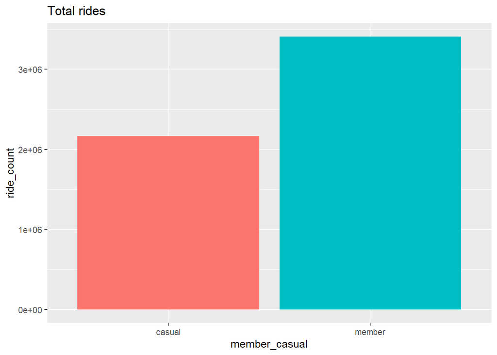

```r
updated_trip_data %>%
  group_by(member_casual) %>%
  summarise(ride_count = length(ride_id)) %>%
  ggplot() + geom_col(mapping = aes(x = member_casual, y = ride_count, fill = member_casual), show.legend = FALSE) +
  labs(title = "Total rides")
```

- **Visualize comparison of total rides with the type of ride**

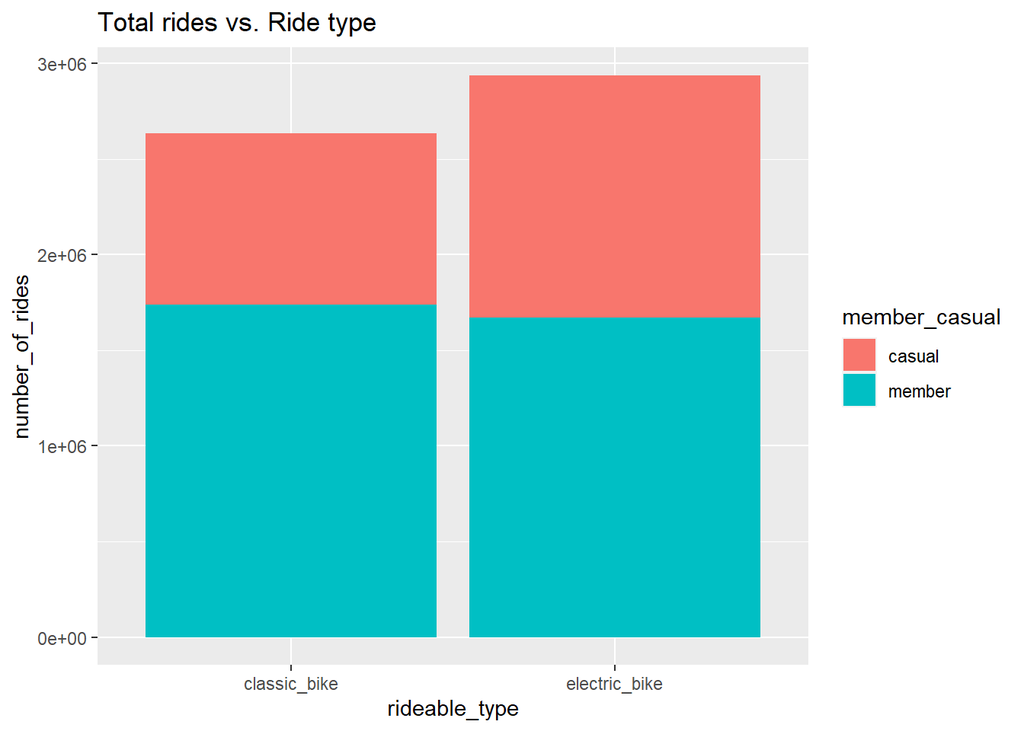

```r
updated_trip_data %>%
  group_by(member_casual, rideable_type) %>%
  summarise(number_of_rides = n(), .groups = "drop") %>%
  ggplot() + geom_col(mapping = aes(x = rideable_type, y = number_of_rides, fill = member_casual), show.legend = TRUE) +
  labs(title = "Total rides vs. Ride type")
```

We can see that member riders slightly prefer classic bikes over electric ones whereas casual riders prefer electric ones.

- **put days of the week in order**

```r
updated_trip_data$day_of_week <- ordered(updated_trip_data$day_of_week,
                                         levels=c("Sunday", "Monday", "Tuesday", "Wednesday", "Thursday", "Friday", "Saturday"))
```

- **Visualize the days of the week with no. of rides taken by riders**

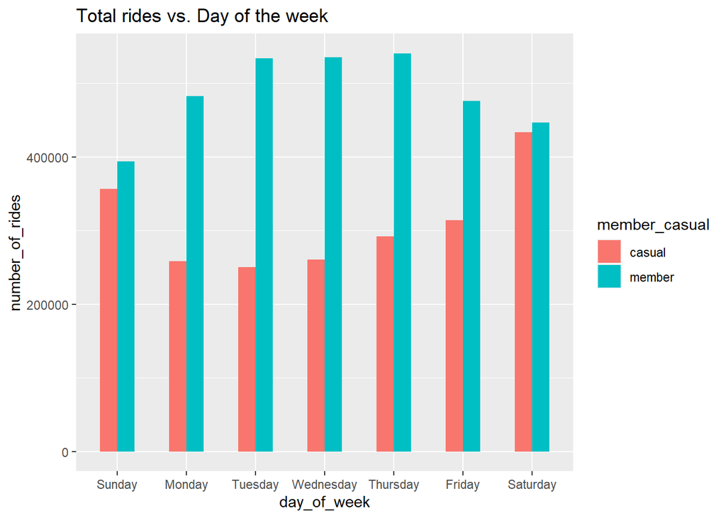

```r
updated_trip_data %>%
  group_by(member_casual, day_of_week) %>%
  summarise(number_of_rides = n(), .groups = "drop") %>%
  arrange(member_casual, day_of_week) %>%
  ggplot(aes(x = day_of_week, y = number_of_rides, fill = member_casual)) +
  labs(title = "Total rides vs. Day of the week") +
  geom_col(width = 0.5, position = position_dodge(width = 0.5)) +
  scale_y_continuous(labels = function(x) format(x,scientific = FALSE))
```

The graph depicts a relationship between the total rides and the day of the week. The lowest total for member riders is Sunday. The highest total for member riders is from Tuesday to Thursday. The lowest total for casual riders is from Monday to Wednesday. The highest total for casual riders is Saturday.

This means that the busiest days for members would be Tuesday to Thursday, with their slowest being Sunday. For casual riders, their busiest days would be Saturday and Sunday and their slowest days would be Monday to Wednesday.

- **Visualize average ride by day of the week**

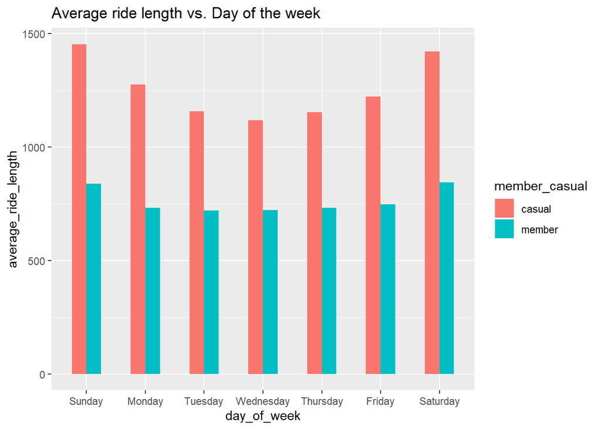

```r
updated_trip_data %>%
  group_by(member_casual, day_of_week) %>%
  summarise(average_ride_length = mean(ride_length), .groups = "drop") %>%
  ggplot(aes(x = day_of_week, y = average_ride_length, fill = member_casual)) +
  geom_col(width = 0.5, position = position_dodge(width = 0.5)) +
  labs(title = "Average ride length vs. Day of the week")
```

- **Visualize average rides by month**

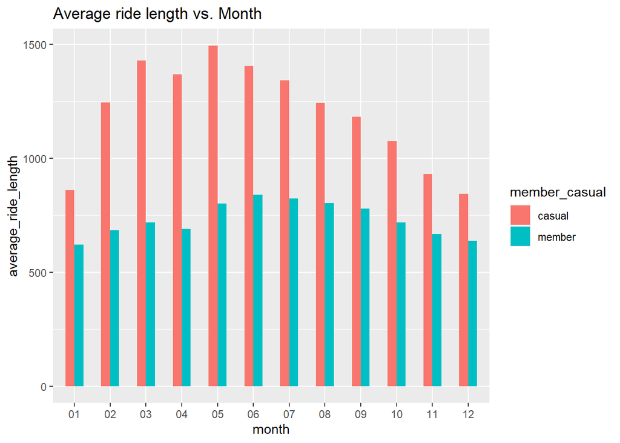

```r
updated_trip_data %>%
  group_by(member_casual, month) %>%
  summarise(average_ride_length = mean(ride_length), .groups = "drop") %>%
  ggplot(aes(x = month, y = average_ride_length, fill = member_casual)) +
  geom_col(width = 0.5, position = position_dodge(width = 0.5)) +
  labs(title = "Average ride length vs. Month")
```

Average ride length for members is fairly consistent with times ranging from 600 seconds to 850 seconds, with the month of June being the longest average ride length. For casual riders, their average ride length ranges between 850 seconds to 1500 seconds, with May being the month with the longest average ride length.

[figure not shown]

```r
updated_trip_data %>%
  group_by(member_casual) %>%
  summarise(average_ride_distance = mean(ride_length)) %>%
  ggplot() + geom_col(mapping = aes(x = member_casual, y = average_ride_distance, fill = member_casual), show.legend = FALSE) +
  labs(title = "Mean distance traveled")
```

### Step 6: Share findings

This phase will be done with a presentation to the stakeholders.

#### Recommendations

1. Marketing and Promotional/Discount campaigns
   - Monthly market emails
     - Provide information on the benefits of being an annual member
   - Discounts
     - The company can offer discounts on a daily, weekly, or monthly basis or based on usage or distanced traveled
2. Host ride events
   - Host ride events on weekends as they are the most popular days for casual riders and offer member benefits and/or free member trial as prizes
3. Offer a weekend-only membership
   - Since casual riders are more active during the weekends it might be a good idea to offer weekend membership passes to encourage them to upgrade their membership status

### Step 7: Act

Ultimately, this stage will be left to the stakeholders and the marketing director to decide after hearing my recommendations.